# System-State — Encoder Heads Greenland 2026

Betriebszustand der drei aktiven Sender: Latenz & Batterie (keine Wissenschaft)

Author

Thom Laepple

Published

September 24, 2026

Dieses Dokument ist **kein** wissenschaftliches Profil, sondern ein **Betriebs-Dashboard** der drei aktiven Systeme:

1. **Latenz** = Empfangszeit (aus dem Rockblock-Export) − interne Messzeit (aus dem Payload mitgesendet). Positiv = Nachricht kommt nach der Messung an (normale Übertragungsverzögerung); **negativ = die interne Uhr läuft der Realzeit voraus** (Empfang „vor” der Messung ist physikalisch unmöglich → Uhr-Offset).
2. **Batteriespannung** (letztes Feld jeder Nachricht) über die Zeit.

Beides je System, direkt vergleichbar.

```r
source("decode_core.R")
suppressMessages({library(dplyr); library(tidyr); library(ggplot2); library(patchwork)})
```

```r
# Die drei aktiven Systeme: IMEI (= .bin-Präfix), Rockblock-Modemseriennr. (so
# heißen sie im CSV-Export), Kopf-Layout (für den robusten Decoder) und Anzeigefarbe.
# Liste (kein tribble) — `fields` ist ein Zeichenvektor pro System.
systems <- list(
  list(key = "grip",  label = "SnowMelt GRIP", imei = "300434065508020",
       modem = "234048", n_nodes = 24L, fields = c("ntc1","ntc2","testSB"),          colour = "#0072B2"),
  list(key = "dye3",  label = "SnowMelt Dye3", imei = "301434062008160",
       modem = "228679", n_nodes = 24L, fields = c("ntc1","ntc2","testSB"),          colour = "#E69F00"),
  list(key = "chain", label = "Doppelkette",   imei = "301434062008130",
       modem = "228680", n_nodes = 20L, fields = c("ntc1","ntc2","gnd","pressure"),  colour = "#009E73")
)
sys_df   <- bind_rows(lapply(systems, function(s)
  data.frame(key = s$key, label = s$label, imei = s$imei, modem = s$modem, colour = s$colour)))
sys_cols <- setNames(sys_df$colour, sys_df$label)

DOWNLOAD_GLOB <- "../download/*.csv"   # Rockblock-Exporte (Empfangszeit lebt nur hier)
TESTDATA_DIR  <- "../testdata"         # .bin (Daten of record) für Zeit + Batterie
```

```r
# Für jedes System alle .bin dekodieren → interne Zeit + Batteriespannung.
# Größen-Filter: gültig, wenn die Datei auf nosep ODER sep passt, jeweils zzgl.
# 0…n_nodes Defekt-Überlaufbytes (ein defekter Sensor sendet ein Byte zu viel).
# Verwirft Garbage (16 B, 47 B …), behält 225/226 (nosep+Defekt) & 300 (sep).
decode_system <- function(s) {
  fields <- s$fields; n_nodes <- s$n_nodes
  exp <- bin_expected_len(n_nodes, fields)
  files <- Sys.glob(file.path(TESTDATA_DIR, paste0(s$imei, "-*.bin")))
  out <- lapply(files, function(f) {
    n <- file.info(f)$size
    ok <- (n - exp$nosep) %in% 0:n_nodes || (n - exp$sep) %in% 0:n_nodes
    if (!ok) return(NULL)
    b <- tryCatch(read_snowchain_bin(f, fields, n_nodes), error = function(e) NULL)
    if (is.null(b)) return(NULL)
    data.frame(imei = s$imei, label = s$label,
               internal = unix2utc(b$time_unix), time_unix = b$time_unix,
               battery_mv = b$battery_mv, battery_partial = b$battery_partial)
  })
  bind_rows(out)
}
bins <- bind_rows(lapply(systems, decode_system))
# battery_partial: ein Defekt-Überlauf hat das Batterie-Lowbyte verschluckt; der
# Wert ist auf ±256 mV rekonstruiert — für einen Zustands-Trend brauchbar, bleibt
# also erhalten (nur als grober markiert).
```

```r
# Empfangszeit aus dem Rockblock-CSV, je Modem, verschlüsselt über die interne Zeit
# des Payloads (erste 4 Byte) → damit an die .bin gejoint. Überlappende Exporte
# werden dedupliziert (gleiche interne Zeit = gleiche Nachricht).
old_lc <- Sys.getlocale("LC_TIME"); Sys.setlocale("LC_TIME", "C")
```

```
[1] "C"
```

```r
csv <- bind_rows(lapply(Sys.glob(DOWNLOAD_GLOB), read.csv, check.names = FALSE))

recv <- csv |>
  filter(Direction == "MO", nchar(trimws(Payload)) >= 400L) |>
  transmute(
    # Modemseriennr. aus "RockBLOCK <nr> - Head_..": Teil vor " -" nehmen, Ziffern
    # behalten (robuster als ein Backreference-sub, das hier leer zurückgab).
    modem   = gsub("[^0-9]", "", sub(" -.*", "", Device)),
    payload = trimws(Payload),
    receipt = as.POSIXct(`Date Time (UTC)`, format = "%d/%b/%Y %H:%M:%S", tz = "UTC")) |>
  filter(modem %in% sys_df$modem) |>
  mutate(time_unix = strtoi(substr(payload, 1L, 8L), 16L),
         imei      = setNames(sys_df$imei, sys_df$modem)[modem]) |>
  distinct(imei, time_unix, .keep_all = TRUE) |>
  select(imei, time_unix, receipt)
Sys.setlocale("LC_TIME", old_lc)
```

```
[1] "C.UTF-8"
```

```r
state <- bins |>
  left_join(recv, by = c("imei", "time_unix")) |>
  mutate(latency_min = as.numeric(difftime(receipt, internal, units = "mins")),
         battery_V   = battery_mv / 1000)
```

## Übersicht

```r
status <- state |> group_by(System = label) |>
  summarise(
    `Nachrichten`      = n(),
    `Letzte Messung (UTC)` = format(max(internal), "%m-%d %H:%M"),
    `Batterie zuletzt (V)` = round(battery_V[which.max(internal)], 2),
    `Batterie min (V)`     = round(min(battery_V, na.rm = TRUE), 2),
    `Latenz Median (min)`  = round(median(latency_min, na.rm = TRUE), 1),
    `mit Empfangszeit`     = sum(!is.na(latency_min)),
    .groups = "drop")
knitr::kable(status, caption = "Betriebszustand je System (Batterie über die gesamte .bin-Historie; Latenz nur wo der Rockblock-Export die Nachricht enthält).")
```

Betriebszustand je System (Batterie über die gesamte .bin-Historie; Latenz nur wo der Rockblock-Export die Nachricht enthält).

| System | Nachrichten | Letzte Messung (UTC) | Batterie zuletzt (V) | Batterie min (V) | Latenz Median (min) | mit Empfangszeit |
| --- | --- | --- | --- | --- | --- | --- |
| Doppelkette | 81 | 09-23 15:13 | 6.54 | 6.44 | 62.0 | 17 |
| SnowMelt Dye3 | 572 | 09-24 09:24 | 6.97 | 6.91 | 61.7 | 61 |
| SnowMelt GRIP | 519 | 09-24 10:15 | 6.66 | 6.66 | -118.3 | 137 |

## Latenz — Empfang minus interne Zeit

Nur Nachrichten, die im Rockblock-Export enthalten sind (dort steht die Empfangszeit). Gestrichelt = 0 (Empfang = Messzeit). Werte **unter** 0 heißen: die interne Uhr des Senders läuft der Realzeit voraus.

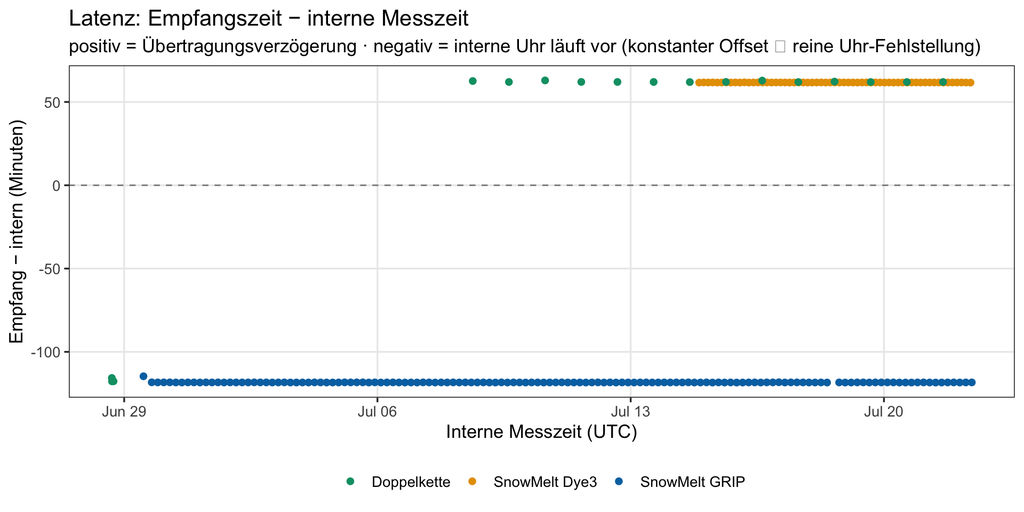

```r
# Punkte statt Linie: die Latenz ist pro Nachricht ein diskreter Uhr-Offset; eine
# verbindende Linie über Datenlücken würde einen Drift vortäuschen, den es nicht gibt.
lat <- state |> filter(!is.na(latency_min))
ggplot(lat, aes(internal, latency_min, colour = label)) +
  geom_hline(yintercept = 0, colour = "grey55", linetype = "dashed") +
  geom_point(size = 1.9) +
  scale_colour_manual(values = sys_cols, name = NULL) +
  labs(title = "Latenz: Empfangszeit − interne Messzeit",
       subtitle = "positiv = Übertragungsverzögerung · negativ = interne Uhr läuft vor (konstanter Offset ⇒ reine Uhr-Fehlstellung)",
       x = "Interne Messzeit (UTC)", y = "Empfang − intern (Minuten)") +
  theme_bw(base_size = 13) +
  theme(legend.position = "bottom", panel.grid.minor = element_blank())
```

```r
sm <- lat |> group_by(label) |>
  summarise(med = median(latency_min), lo = min(latency_min), hi = max(latency_min), .groups = "drop")
cat("Median-Latenz je System: ",
    paste(sprintf("**%s %+.0f min**", sm$label, sm$med), collapse = ", "),
    ". Ein konstant negativer Wert ist ein reiner **Uhr-Offset** (interne Uhr zu schnell gestellt), ",
    "kein Übertragungsproblem — die Uhr ließe sich per `SC`-Kommando neu setzen.\n", sep = "")
```

Median-Latenz je System: **Doppelkette +62 min**, **SnowMelt Dye3 +62 min**, **SnowMelt GRIP -118 min**. Ein konstant negativer Wert ist ein reiner **Uhr-Offset** (interne Uhr zu schnell gestellt), kein Übertragungsproblem — die Uhr ließe sich per `SC`-Kommando neu setzen.

### Feinstruktur — Offset abgezogen

Der große Offset (GRIP ~−2 h, Dye3/Chain ~+1 h) überdeckt die eigentliche Variation. Hier ist je System der **eigene Median abgezogen**, freie y-Achse pro System, damit die **Tag-zu-Tag-Streuung in Sekunden** sichtbar wird. So sieht man, wie stabil Uhr + Übertragung tatsächlich sind (und wo einzelne Nachrichten später ankommen — spätere Satellitenpässe/Retries).

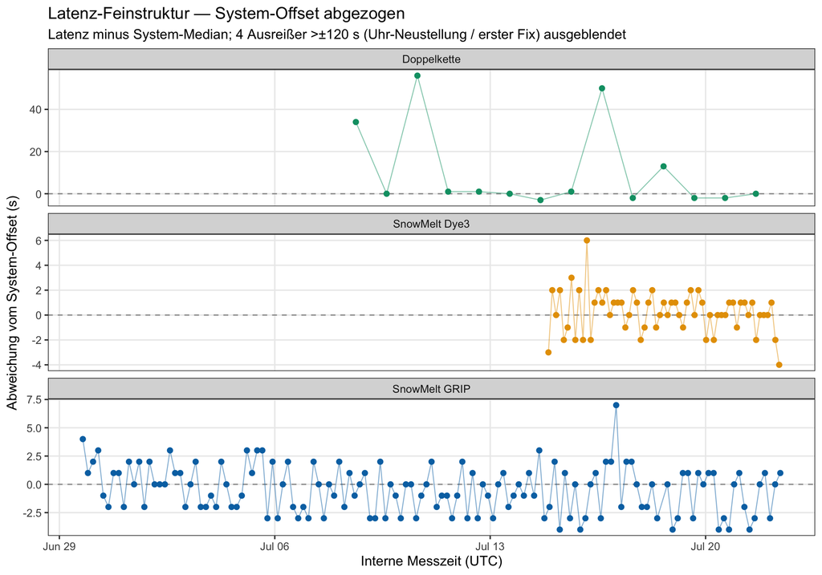

```r
LAT_FINE_S <- 120   # Ausreißer über ±2 min = Uhr-Neustellung / erster Fix, nicht Alltag
fine <- lat |> group_by(label) |>
  mutate(resid_s = (latency_min - median(latency_min)) * 60) |> ungroup()
n_out <- sum(abs(fine$resid_s) > LAT_FINE_S)
fine_in <- fine |> filter(abs(resid_s) <= LAT_FINE_S)

ggplot(fine_in, aes(internal, resid_s, colour = label)) +
  geom_hline(yintercept = 0, colour = "grey60", linetype = "dashed") +
  geom_line(linewidth = 0.4, alpha = 0.5) + geom_point(size = 1.9) +
  scale_colour_manual(values = sys_cols, guide = "none") +
  facet_wrap(~ label, scales = "free_y", ncol = 1) +
  labs(title = "Latenz-Feinstruktur — System-Offset abgezogen",
       subtitle = sprintf("Latenz minus System-Median; %d Ausreißer >±%d s (Uhr-Neustellung / erster Fix) ausgeblendet",
                          n_out, LAT_FINE_S),
       x = "Interne Messzeit (UTC)", y = "Abweichung vom System-Offset (s)") +
  theme_bw(base_size = 12) + theme(panel.grid.minor = element_blank())
```

```r
sd_tab <- fine_in |> group_by(label) |>
  summarise(sd = round(sd(resid_s), 1), hi = round(max(resid_s), 0), .groups = "drop")
cat("Streuung um den Offset (SD / Maximum): ",
    paste(sprintf("**%s %.1f s / %+.0f s**", sd_tab$label, sd_tab$sd, sd_tab$hi), collapse = ", "),
    ". Uhr und Übertragung sind auf wenige Sekunden stabil; einzelne Spitzen = später ",
    "abgesetzte Nachricht (nächster Iridium-Pass).\n", sep = "")
```

Streuung um den Offset (SD / Maximum): **Doppelkette 20.5 s / +56 s**, **SnowMelt Dye3 1.6 s / +6 s**, **SnowMelt GRIP 2.1 s / +7 s**. Uhr und Übertragung sind auf wenige Sekunden stabil; einzelne Spitzen = später abgesetzte Nachricht (nächster Iridium-Pass).

## Batteriespannung

Offene Symbole = **nur Highbyte** rekonstruiert (ein Defektsensor hat das Batterie-Lowbyte verschluckt): der Wert stimmt auf **±256 mV**, ist aber auf 256-mV-Stufen quantisiert — daher wirkt so eine Reihe künstlich konstant. Bei GRIP betrifft das praktisch alle Nachrichten; Dye3 und Chain haben die volle Auflösung.

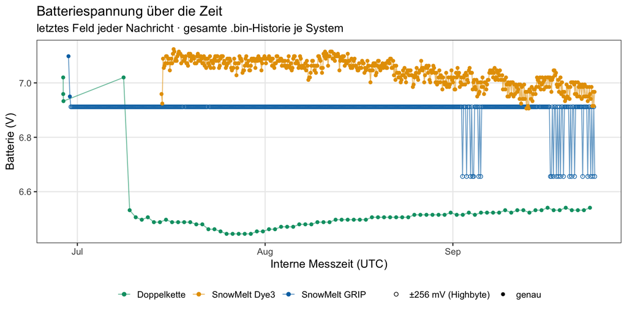

```r
batt <- state |> filter(!is.na(battery_V)) |>
  mutate(Auflösung = ifelse(battery_partial, "±256 mV (Highbyte)", "genau"))
ggplot(batt, aes(internal, battery_V, colour = label)) +
  geom_line(linewidth = 0.5, alpha = 0.6) +
  geom_point(aes(shape = Auflösung), size = 1.8) +
  scale_colour_manual(values = sys_cols, name = NULL) +
  scale_shape_manual(values = c("genau" = 16, "±256 mV (Highbyte)" = 1), name = NULL) +
  labs(title = "Batteriespannung über die Zeit",
       subtitle = "letztes Feld jeder Nachricht · gesamte .bin-Historie je System",
       x = "Interne Messzeit (UTC)", y = "Batterie (V)") +
  theme_bw(base_size = 13) +
  theme(legend.position = "bottom", panel.grid.minor = element_blank())
```

```r
bs <- batt |> group_by(label) |>
  summarise(first = battery_V[which.min(internal)], last = battery_V[which.max(internal)],
            min = min(battery_V), .groups = "drop") |>
  mutate(trend = last - first)
cat("Batterie zuletzt / Trend über den Zeitraum: ",
    paste(sprintf("**%s %.2f V (%+.2f V)**", bs$label, bs$last, bs$trend), collapse = ", "),
    ". Der Abfall der Doppelkette (~0,5 V um den Einbau) ist echt (volle Auflösung); ",
    "GRIPs scheinbar konstante Linie ist das Highbyte-Artefakt.\n", sep = "")
```

Batterie zuletzt / Trend über den Zeitraum: **Doppelkette 6.54 V (-0.48 V)**, **SnowMelt Dye3 6.97 V (+0.01 V)**, **SnowMelt GRIP 6.66 V (-0.44 V)**. Der Abfall der Doppelkette (~0,5 V um den Einbau) ist echt (volle Auflösung); GRIPs scheinbar konstante Linie ist das Highbyte-Artefakt.